# JHU Data Science Specialization: Reproducible Research

Devara Izaz Fathan

8/18/2020

# 1. Synopsis

The aim of this project is to explore the NOAA Storm Database and explore the effects of severe weather events on both population and economy.The database covers the time period between 1950 and November 2011. This database tracks characteristics of major storms and weather events in the United States, including when and where they occur, as well as estimates of any fatalities, injuries, and property damage. The following analysis investigates which types of severe weather events are most harmful according to the following questions:

1. Across the United States, which types of events are most harmful with respect to population health?
2. Across the United States, which types of events have the greatest economic consequences?

# 2. Data Processing

## 2.1 Data Loading

Download the data from [Storm Data](https://d396qusza40orc.cloudfront.net/repdata%2Fdata%2FStormData.csv.bz2) and unzip the file using the function in R. We also have to add the library that will be used in this project.

```r
library(tidyverse)
```

```r
library(dplyr)
library(knitr)
library(ggplot2)
url <- 'https://d396qusza40orc.cloudfront.net/repdata%2Fdata%2FStormData.csv.bz2'
dest <- download.file(url, 'E:/BELAJAR CODING/R/COURSERA/U.S.-National-Oceanic-and-Atmospheric-Administration-s-NOAA/repdata_data_StormData.csv.bz2')
storm_data <- read.csv('repdata_data_StormData.csv.bz2')
```

## 2.2 List of Column Names

```r
colnames(storm_data)
```

```
##  [1] "STATE__"    "BGN_DATE"   "BGN_TIME"   "TIME_ZONE"  "COUNTY"
##  [6] "COUNTYNAME" "STATE"      "EVTYPE"     "BGN_RANGE"  "BGN_AZI"
## [11] "BGN_LOCATI" "END_DATE"   "END_TIME"   "COUNTY_END" "COUNTYENDN"
## [16] "END_RANGE"  "END_AZI"    "END_LOCATI" "LENGTH"     "WIDTH"
## [21] "F"          "MAG"        "FATALITIES" "INJURIES"   "PROPDMG"
## [26] "PROPDMGEXP" "CROPDMG"    "CROPDMGEXP" "WFO"        "STATEOFFIC"
## [31] "ZONENAMES"  "LATITUDE"   "LONGITUDE"  "LATITUDE_E" "LONGITUDE_"
## [36] "REMARKS"    "REFNUM"
```

## 2.3 Changing the COlumn Names

We need to change some column names that most frequently used such as PROPDMG, PROPDMGEXP, CROPDMG, CROPDMGEXP

```r
colnames(storm_data)[25:28] <- c('Damage', 'Exp', 'CropDamage', 'CropExp')
head(storm_data[,25:28])
```

```
##   Damage Exp CropDamage CropExp
## 1   25.0   K          0
## 2    2.5   K          0
## 3   25.0   K          0
## 4    2.5   K          0
## 5    2.5   K          0
## 6    2.5   K          0
```

## 2.4 Choosing Columns

We need to subset the data into table that contain column that we only use in this analysis

```r
storm_data <- storm_data %>% select(EVTYPE, FATALITIES, INJURIES, Damage, Exp, CropDamage, CropExp)
head(storm_data)
```

```
##    EVTYPE FATALITIES INJURIES Damage Exp CropDamage CropExp
## 1 TORNADO          0       15   25.0   K          0
## 2 TORNADO          0        0    2.5   K          0
## 3 TORNADO          0        2   25.0   K          0
## 4 TORNADO          0        2    2.5   K          0
## 5 TORNADO          0        2    2.5   K          0
## 6 TORNADO          0        6    2.5   K          0
```

## 2.5 Convert Exp and CropExp to Actual Value

We need to do this for easier calculation of getting actual cost.

```r
for(i in 1:nrow(storm_data)){
      exp <- storm_data$Exp[i]
      if(exp==''){storm_data$Exp[i] <- 0}
      if(exp=='-'){storm_data$Exp[i] <- 10^0}
      if(exp=='+'){storm_data$Exp[i] <- 10^0}
      if(exp=='0'){storm_data$Exp[i] <- 10^0}
      for (n in 1:9){
            if(exp == as.character(n)){storm_data$Exp[i] <- 10^n}
      }
      if(exp=='H'){storm_data$Exp[i] <- 10^2}
      if(exp=='K'){storm_data$Exp[i] <- 10^3}
      if(exp=='M'){storm_data$Exp[i] <- 10^6}
      if(exp=='B'){storm_data$Exp[i] <- 10^9}
      if(exp=='h'){storm_data$Exp[i] <- 10^2}
      if(exp=='m'){storm_data$Exp[i] <- 10^6}
      if(exp=='?'){storm_data$Exp[i] <- 10^0}
}
```

```r
for (i in 1:nrow(storm_data)){
      expcrop <- storm_data$CropExp[i]
      if(expcrop==''){storm_data$CropExp[i] <- 0}
      if(expcrop=='?'){storm_data$CropExp[i] <- 10^0}
      if(expcrop=='0'){storm_data$CropExp[i] <- 10^0}
      if(expcrop=='2'){storm_data$CropExp[i] <- 10^2}
      if(expcrop=='B'){storm_data$CropExp[i] <- 10^9}
      if(expcrop=='M'){storm_data$CropExp[i] <- 10^6}
      if(expcrop=='m'){storm_data$CropExp[i] <- 10^6}
      if(expcrop=='K'){storm_data$CropExp[i] <- 10^3}
      if(expcrop=='k'){storm_data$CropExp[i] <- 10^3}
}
```

## 2.6 Calculating Total Property and Crop Cost Damage

```r
storm_data$Exp <- as.numeric(storm_data$Exp)
storm_data$CropExp <- as.numeric(storm_data$CropExp)
damage <- storm_data %>% group_by(EVTYPE) %>%
      summarize(prop_damage= sum(Damage*Exp), crop_damage = sum(CropDamage*CropExp), total_damage = (prop_damage + crop_damage)) %>%
      arrange(desc(total_damage))
```

# 3. Result

## 3.1 Most Dangerous Event to Population Health

```r
head(fatality, 10)
```

```
## # A tibble: 10 x 4
##    EVTYPE            fatalities injury total
##    <chr>                  <dbl>  <dbl> <dbl>
##  1 TORNADO                 5633  91346 96979
##  2 EXCESSIVE HEAT          1903   6525  8428
##  3 TSTM WIND                504   6957  7461
##  4 FLOOD                    470   6789  7259
##  5 LIGHTNING                816   5230  6046
##  6 HEAT                     937   2100  3037
##  7 FLASH FLOOD              978   1777  2755
##  8 ICE STORM                 89   1975  2064
##  9 THUNDERSTORM WIND        133   1488  1621
## 10 WINTER STORM             206   1321  1527
```

The most harmful event to Population Health is **TORNADO** .We can see it in the histogram below.

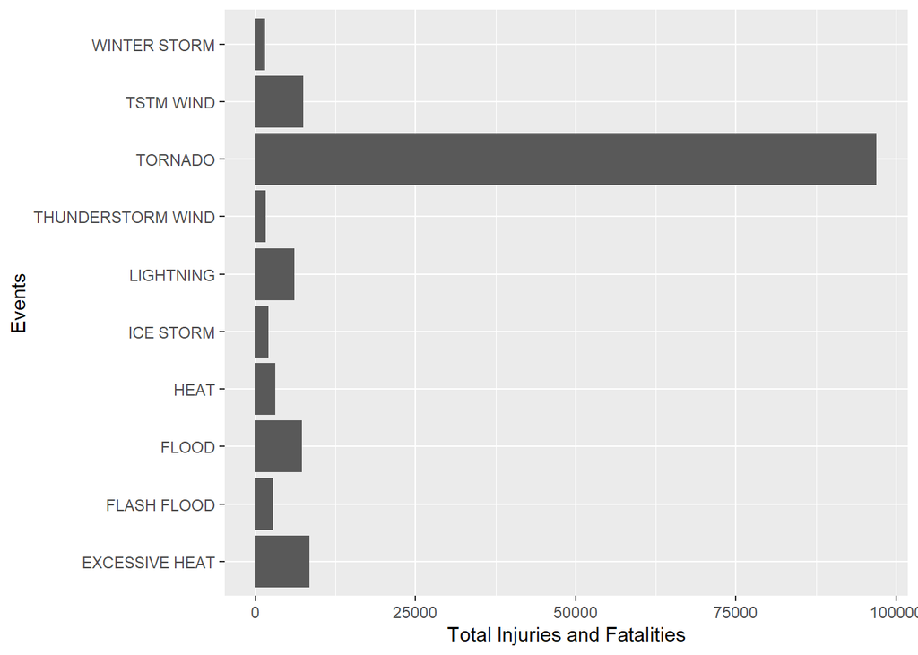

```r
fatality[1:10,]  %>% ggplot(aes(EVTYPE, total)) +
      geom_bar(stat='identity') +
      xlab('Events') +
      ylab('Total Injuries and Fatalities') +
      coord_flip()
```

## 3.2 Most Dangerous Event to Economic Consequences

```r
head(damage, 10)
```

```
## # A tibble: 10 x 4
##    EVTYPE              prop_damage crop_damage  total_damage
##    <chr>                     <dbl>       <dbl>         <dbl>
##  1 FLOOD             144657709800   5661968450 150319678250
##  2 HURRICANE/TYPHOON  69305840000   2607872800  71913712800
##  3 TORNADO            56947380674.   414953270  57362333944.
##  4 STORM SURGE        43323536000         5000  43323541000
##  5 HAIL               15735267456.  3025954470  18761221926.
##  6 FLASH FLOOD        16822673772.  1421317100  18243990872.
##  7 DROUGHT             1046106000  13972566000  15018672000
##  8 HURRICANE          11868319010   2741910000  14610229010
##  9 RIVER FLOOD         5118945500   5029459000  10148404500
## 10 ICE STORM           3944927860   5022113500   8967041360
```

The most harmful Event to Economic Consequences is **FLOOD**. We can see it in the histogram below.

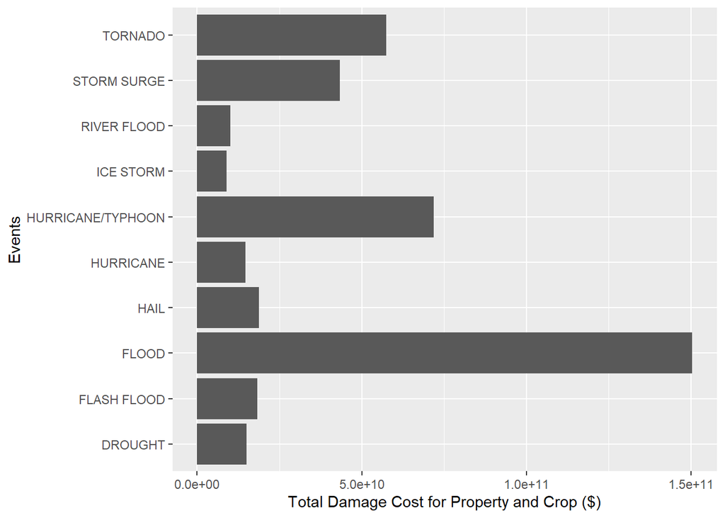

```r
damage[1:10, ] %>% ggplot(aes(EVTYPE, total_damage)) +
      geom_histogram(stat='identity') +
      xlab('Events') +
      ylab('Total Damage Cost for Property and Crop ($)') +
      coord_flip()
```